# Analyzing Client Bike Rentals

## by Deepak Nandipati

# Investigation Overview

> My analysis of the datasets was to determine which group of individuals are likely to have the longest rental duration and to find out what timespread these riders are most active in San Franciso.

## Dataset Overview

> This dataset contains of trip information of more than 400,000 data points of bike rentals from the year 2017, data consists from June 2017 to December 2017. Using variables such as start_times and end_times and along with user details we can deduce many conclusions. Data was thoroughly cleaned from null values, duplicates and funneled to answer our necessary questions.

## Determining the busiest times of the day

> In analysis there was a particular pattern that was observed, which was of the time of day the rentals were most active. Rentals are most accurate during the business hours with most rentals starting during work times and ending after work. This shows us that most rentals are working class people using it for commuting. The graph below has a bimodal shape, which indicates to us that it has two peaks - one at 8:00AM (count of 54,086) and another at 5:00PM (count of 53,828).  
> The other graph below will indicate the count for days of the week. Monday to Friday being the busiest, which further supports our theory of bike rentals are being used for commuting to work.

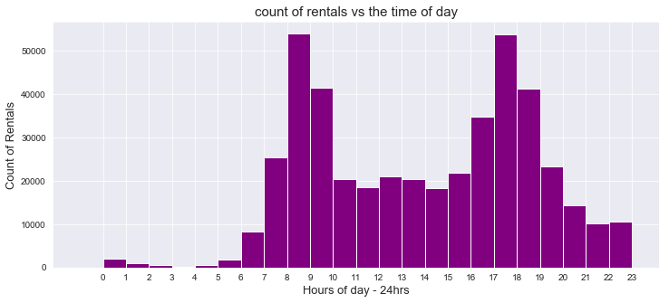

```python
sns.set_style("darkgrid")
binsize = 1
bins = np.arange(-1, df_clean['start_hour'].max()+binsize, binsize)

plt.figure(figsize=[12, 5])
plt.hist(data = df_clean, x = 'start_hour', color = 'purple', bins=bins)
plt.xlabel("Hours of day - 24hrs", fontsize=13)
plt.ylabel("Count of Rentals", fontsize=13)
plt.title("count of rentals vs the time of day", fontsize=15)
plt.xticks(range(24))

plt.show()
```

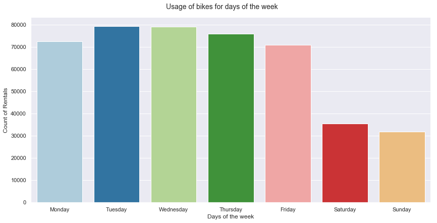

```python
#Count of bike rentals from June to Dec, 2017
sns.set(font_scale=1)
weekday = ['Monday', 'Tuesday', 'Wednesday', 'Thursday', 'Friday', 'Saturday', 'Sunday']

g = sns.catplot(data= df_clean, x='start_day', kind='count', palette="Paired", order=weekday, height=6, aspect=2)

g.set_axis_labels("Days of the week", "Count of Rentals")
g.fig.suptitle('Usage of bikes for days of the week', y=1.02, fontsize=14);
```

## Age groups and their rental counts

> Dividing the ages to groups to determine which age groups have the highest rates of rentals. Plotting shows age groups 30-40 have the highest count of rentals, followed by 20-30. Suprisingly, the age ranges 10-20 are the lowest, even lower than 60-70.

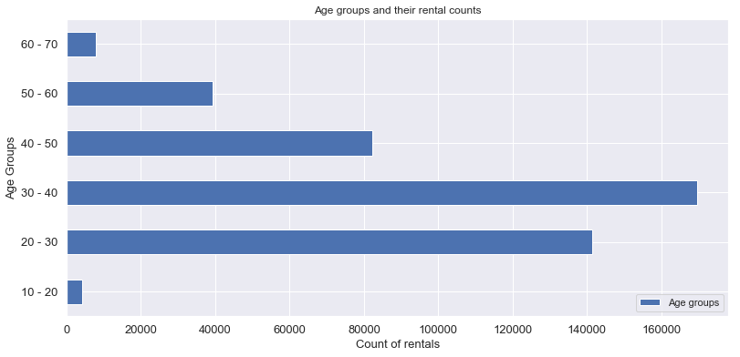

```python
plotG = new_df.plot.barh(fontsize = 13)

#title and axis labelling
plotG.set(title = 'Age groups and their rental counts')
plotG.set_xlabel('Count of rentals', fontsize = '13')
plotG.set_ylabel('Age Groups',  fontsize = '13')

pltG_label= ['Age groups']
plt.legend(pltG_label, loc='lower right')

#adjusting plot size
plotG.figure.set_size_inches(13, 6)

plt.show()
```

## Subscription type vs. Average trip duration

> Customers and Subscribers had an interesting differences in average durations. It is shown that Subscribers have less rental time compared to the customer durations, this may be because subscribers only need the rentals for daily commuting while a typical customer may only use it for leisure drive.

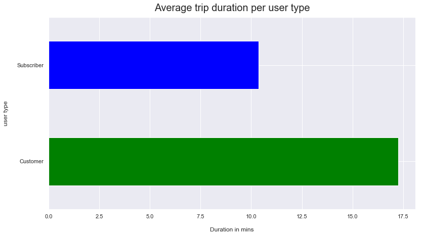

```python
#plottingg user_type against duration
new_color=['green', 'blue']
ax = df_clean.groupby('user_type')['duration_min'].mean().plot(kind='barh', color=new_color, figsize=(13,7))

ax.set_title('Average trip duration per user type', fontsize=20, y=1.015)
ax.set_ylabel('user type', labelpad=16)
ax.set_xlabel('Duration in mins', labelpad=16);
```

## Subscription type and Genders vs. Average trip duration

The plot shows brief summary of the distrubtion of data by comparing it to variables such as start time, duration of rental and riders age.

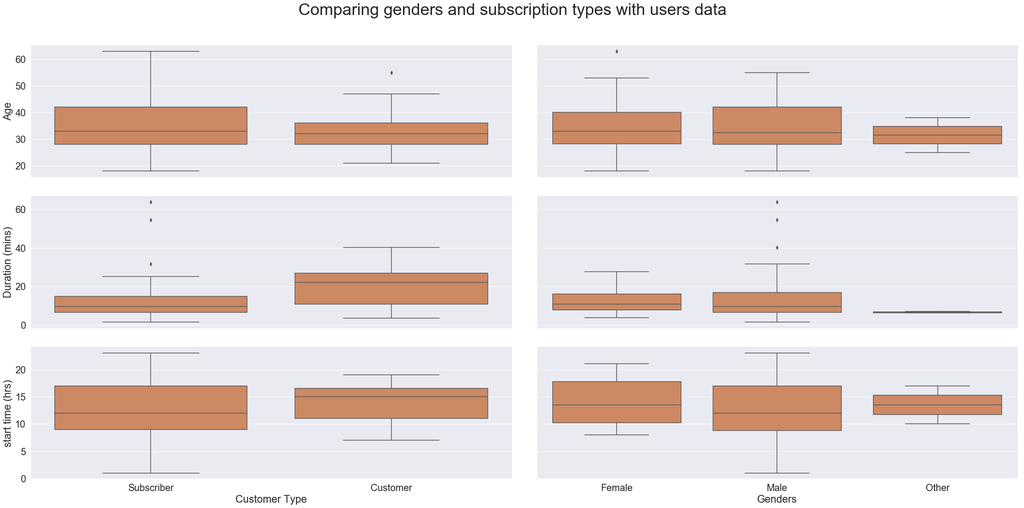

```python
samples = np.random.choice(df_clean.shape[0], 100, replace = False)
data_samp = df_clean.loc[samples,:]

def boxplt(x, y, **kwargs):
    default_color = sns.color_palette()[1]
    sns.boxplot(x, y, color = default_color)

sns.set(font_scale=1.8)

g = sns.PairGrid(data = data_samp, y_vars = ['rider_age', 'duration_min', 'start_hour'], x_vars = category_vars1,
                height = 5, aspect = 3)

g.fig.subplots_adjust(top=0.9)
g.fig.suptitle('Comparing genders and subscription types with users data', fontsize=34)
g.map(boxplt)

for i in range(3):
    for j in range(2):
        xlabel = g.axes[i][j].get_xlabel()
        ylabel = g.axes[i][j].get_ylabel()
        if xlabel in xreplacements.keys():
            g.axes[i][j].set_xlabel(xreplacements[xlabel])
        if ylabel in yreplacements.keys():
            g.axes[i][j].set_ylabel(yreplacements[ylabel])


plt.show();
```

## Comparing genders/subscription type with Duration in mins

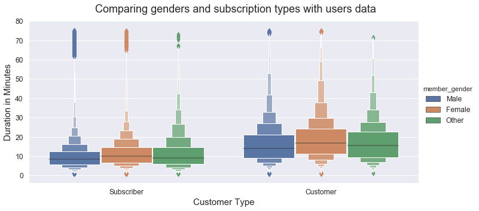

```python
sns.set(font_scale=1.1)


h = sns.catplot(data=df_clean, x='user_type', y="duration_min", hue="member_gender", kind="boxen", height = 5, aspect = 2)

h.fig.suptitle('Comparing genders and subscription types with users data', fontsize=18)

h.fig.subplots_adjust(top=0.9);
plt.xlabel("Customer Type", fontsize=15)
plt.ylabel("Duration in Minutes", fontsize=15)


plt.show();
```